# P2 project

## data

SPECIAL NOTES: Pclass is a proxy for socio-economic status (SES) 1st ~ Upper; 2nd ~ Middle; 3rd ~ Lower

Age is in Years; Fractional if Age less than One (1) If the Age is Estimated, it is in the form xx.5

With respect to the family relation variables (i.e. sibsp and parch) some relations were ignored. The following are the definitions used for sibsp and parch.

Sibling: Brother, Sister, Stepbrother, or Stepsister of Passenger Aboard Titanic Spouse: Husband or Wife of Passenger Aboard Titanic (Mistresses and Fiances Ignored) Parent: Mother or Father of Passenger Aboard Titanic Child: Son, Daughter, Stepson, or Stepdaughter of Passenger Aboard Titanic

Other family relatives excluded from this study include cousins, nephews/nieces, aunts/uncles, and in-laws. Some children travelled only with a nanny, therefore parch=0 for them. As well, some travelled with very close friends or neighbors in a village, however, the definitions do not support such relations.

# Which age of passenger survived more?

# Does age affect whether they survive or not?

# Does pclass affect whether they survive or not?

```python
### data
import matplotlib.pyplot as plt
import numpy as np
import pandas as pd

titanic = pd.read_csv('C:/Users/JuHyung Son/Desktop/Python/csv/titanic_data.csv')
```

# Problem in data

there are 'None' and 'xx.5' ages in age column. there are 'None' cabin.

# Data Wrangling 1

#### Estimated age (xx.5) as (xx) (change it to int())

```python
titanic['Age'] = titanic['Age'].fillna(1)
titanic['Age'] = titanic['Age'].astype(int)
```

#### In analysis 'None' in cabin doesn' t need to be change.

#### because there's no empty value such as '0', it's just 'None'

#### Also in 'Ticket' column, integer and 'S.C./A.4. 23567' or something is mixed, but it's okay. I let their dtype just 'object'

## Which age of passenger survived more?

## people who survived

```python
survived_passenger = titanic[titanic.Survived == 1]
```

## and their Age in plot and summary

```
count    342.000000
mean      24.169591
std       16.935799
min        0.000000
25%        7.250000
50%       25.000000
75%       35.000000
max       80.000000
Name: Age, dtype: float64
```

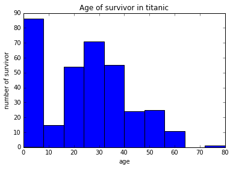

```python
age_of_survivor = survived_passenger['Age']
%pylab inline
age_of_survivor.plot(kind='hist')
plt.xlabel('age')
plt.ylabel('number of survivor')
plt.title('Age of survivor in titanic')

age_of_survivor.describe()
```

##### from the summary and plot of age of survivor.

##### we can see relatively young passengers survived more.

## But I need to know whether there were more young passengers than olders or people wanted to save youngers.

## I expect people tried to save more youngers.

#### I split passengers by age. then plot and summary it.

```
count    891.000000
mean      23.982043
std       17.331057
min        0.000000
25%        6.000000
50%       24.000000
75%       35.000000
max       80.000000
Name: Age, dtype: float64
```

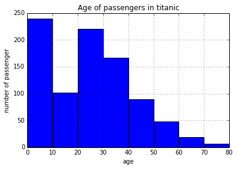

```python
passenger_age = titanic['Age']
passenger_age.plot(kind='hist', bins=8)
plt.ylabel('number of passenger')
plt.xlabel('age')
plt.title('Age of passengers in titanic')
plt.grid(True)

passenger_age.describe()
```

#### It is very similar with passenger plot.

#### Sadly it seems youngers survived more because youngers were more than olders

#### But I need to look it precisely with rate of survivor in each age.

### To know the rate of survivor in each age, I need a dataframe that has number of passenger.

### I made 2 data frames, one is the number of entire passengers' age